# Home 4: Build a CNN for image recognition.

## 0. You will do the following:

1. Read, complete, and run the code.
2. **Make substantial improvements** to maximize the accurcy.
3. Convert the .IPYNB file to .HTML file.
   - The HTML file must contain the code and the output after execution.
   - Missing **the output after execution** will not be graded.
4. Upload this .HTML file to your Google Drive, Dropbox, or Github repo. (If you submit the file to Google Drive or Dropbox, you must make the file "open-access". The delay caused by "deny of access" may result in late penalty.)
5. Submit the link to this .HTML file to Canvas.
   - Example: https://github.com/wangshusen/CS583-2020S/blob/master/homework/HM4/HM4.html

## Requirements:

1. You can use whatever CNN architecture, including VGG, Inception, and ResNet. However, you must build the networks layer by layer. You must NOT import the archetectures from `keras.applications`.
2. Make sure `BatchNormalization` is between a `Conv`/`Dense` layer and an `activation` layer.
3. If you want to regularize a `Conv`/`Dense` layer, you should place a `Dropout` layer **before** the `Conv`/`Dense` layer.
4. An accuracy above 70% is considered reasonable. An accuracy above 80% is considered good. Without data augmentation, achieving 80% accuracy is difficult.

## Google Colab

- If you do not have GPU, the training of a CNN can be slow. Google Colab is a good option.
- Keep in mind that you must download it as an IPYNB file and then use IPython Notebook to convert it to HTML.
- Also keep in mind that the IPYNB and HTML files must contain the outputs. (Otherwise, the instructor will not be able to know the correctness and performance.) Do the followings to keep the outputs.
- In Colab, go to `Runtime` --> `Change runtime type` --> Do NOT check `Omit code cell output when saving this notebook`. In this way, the downloaded IPYNB file contains the outputs.

## 1. Data preparation

### 1.1. Load data

```python
from keras.datasets import cifar10
import numpy

(x_train, y_train), (x_test, y_test) = cifar10.load_data()
mean = numpy.mean(x_train,axis=(0,1,2,3))
std = numpy.std(x_train,axis=(0,1,2,3))
x_train = (x_train-mean)/(std+1e-7)
x_test = (x_test-mean)/(std+1e-7)

print('shape of x_train: ' + str(x_train.shape))
print('shape of y_train: ' + str(y_train.shape))
print('shape of x_test: ' + str(x_test.shape))
print('shape of y_test: ' + str(y_test.shape))
print('number of classes: ' + str(numpy.max(y_train) - numpy.min(y_train) + 1))
```

```
shape of x_train: (50000, 32, 32, 3)
shape of y_train: (50000, 1)
shape of x_test: (10000, 32, 32, 3)
shape of y_test: (10000, 1)
number of classes: 10
```

### 1.2. One-hot encode the labels

In the input, a label is a scalar in $\{0, 1, \cdots , 9\}$. One-hot encode transform such a scalar to a $10$-dim vector. E.g., a scalar `y_train[j]=3` is transformed to the vector `y_train_vec[j]=[0, 0, 0, 1, 0, 0, 0, 0, 0, 0]`.

1. Define a function `to_one_hot` that transforms an $n\times 1$ array to a $n\times 10$ matrix.
2. Apply the function to `y_train` and `y_test`.

```python
def to_one_hot(y, num_class=10):
    temp = numpy.zeros(shape=(y.shape[0],num_class))
    for i in range(y.shape[0]):
        temp[i,y[i]] = 1
    return temp

y_train_vec = to_one_hot(y_train)
y_test_vec = to_one_hot(y_test)

print('Shape of y_train_vec: ' + str(y_train_vec.shape))
print('Shape of y_test_vec: ' + str(y_test_vec.shape))

print(y_train[0])
print(y_train_vec[0])
```

```
Shape of y_train_vec: (50000, 10)
Shape of y_test_vec: (10000, 10)
[6]
[0. 0. 0. 0. 0. 0. 1. 0. 0. 0.]
```

#### Remark: the outputs should be

- Shape of y_train_vec: (50000, 10)
- Shape of y_test_vec: (10000, 10)
- [6]
- [0. 0. 0. 0. 0. 0. 1. 0. 0. 0.]

### 1.3. Randomly partition the training set to training and validation sets

Randomly partition the 50K training samples to 2 sets:

- a training set containing 40K samples
- a validation set containing 10K samples

```python
rand_indices = numpy.random.permutation(50000)
train_indices = rand_indices[0:40000]
valid_indices = rand_indices[40000:50000]

x_val = x_train[valid_indices, :]
y_val = y_train_vec[valid_indices, :]

x_tr = x_train[train_indices, :]
y_tr = y_train_vec[train_indices, :]


print('Shape of x_tr: ' + str(x_tr.shape))
print('Shape of y_tr: ' + str(y_tr.shape))
print('Shape of x_val: ' + str(x_val.shape))
print('Shape of y_val: ' + str(y_val.shape))
```

```
Shape of x_tr: (40000, 32, 32, 3)
Shape of y_tr: (40000, 10)
Shape of x_val: (10000, 32, 32, 3)
Shape of y_val: (10000, 10)
```

## 2. Build a CNN and tune its hyper-parameters

1. Build a convolutional neural network model
2. Use the validation data to tune the hyper-parameters (e.g., network structure, and optimization algorithm)
   - Do NOT use test data for hyper-parameter tuning!!!
3. Try to achieve a validation accuracy as high as possible.

### Remark:

The following CNN is just an example. You are supposed to make **substantial improvements** such as:

- Add more layers.
- Use regularizations, e.g., dropout.
- Use batch normalization.

```python
from keras.layers import GlobalMaxPooling2D, ZeroPadding2D, Conv2D, MaxPooling2D, Flatten, Dense, Dropout, BatchNormalization, Activation, Input, Add
from keras.models import Sequential, Model

# def resnet_identity_block(x,filters,kernel_size):
#     x_skip = x
#     x = Conv2D(filters=filters,kernel_size=(kernel_size,kernel_size),padding='same')(x)
#     x = BatchNormalization(axis=3)(x)
#     x = Activation('relu')(x)
#     x = Conv2D(filters=filters,kernel_size=(kernel_size,kernel_size),padding='same')(x)
#     x = BatchNormalization(axis=3)(x)
#     x = Activation('relu')(x)
#     x = Add()([x,x_skip])
#     x = Activation('relu')(x)
#     return x
#
# def resnet_cov_block(x,filters,kernel_size):
#     x_skip = Conv2D(filters=filters,kernel_size=(kernel_size,kernel_size),padding='same')(x)
#     x_skip = BatchNormalization(axis=3)(x_skip)
#     x = Conv2D(filters=filters,kernel_size=(kernel_size,kernel_size),padding='same')(x)
#     x = BatchNormalization(axis=3)(x)
#     x = Activation('relu')(x)
#     x = Conv2D(filters=filters,kernel_size=(kernel_size,kernel_size),padding='same')(x)
#     x = BatchNormalization(axis=3)(x)
#     x = Activation('relu')(x)
#     x = Add()([x,x_skip])
#     x = Activation('relu')(x)
#     return x
#
# def resnet(shape = (32,32,3)):
#     x_input = Input(shape)
#     x = x_input
#     x = Conv2D(32,(3,3),padding='same',input_shape=shape, name="input_layor")(x)
#     x = BatchNormalization(axis=3)(x)
#     x = Activation('relu')(x)
#     x = resnet_identity_block(x,32,3)
#     x = MaxPooling2D(2,2)(x)
#     x = resnet_cov_block(x,64,3)
#     x = MaxPooling2D(2,2)(x)
#     x = Flatten()(x)
#     x = Dropout(0.4)(x)
#     x = Dense(16)(x)
#     x = BatchNormalization()(x)
#     x = Activation('relu')(x)
#     x = Dense(16)(x)
#     x = BatchNormalization()(x)
#     x = Activation('relu')(x)
#     x = Dense(10, activation='softmax')(x)
#     model = Model(inputs = x_input, outputs = x)
#     return model
#
# model = resnet((32,32,3))
# model.summary()

model = Sequential()
model.add(Conv2D(32, (3, 3), padding='same',input_shape=(32, 32, 3)))
model.add(Activation('relu'))
model.add(Conv2D(32, (3, 3), padding= 'same'))
model.add(Activation('relu'))
model.add(Conv2D(32, (3, 3), padding= 'same'))
model.add(Activation('relu'))
model.add(MaxPooling2D((2, 2)))
model.add(Conv2D(64, (3, 3), padding= 'same'))
model.add(Activation('relu'))
model.add(Conv2D(64, (3, 3), padding= 'same'))
model.add(Activation('relu'))
model.add(MaxPooling2D((2, 2)))
model.add(Dropout(0.3))
model.add(Conv2D(128, (3, 3), padding= 'same'))
model.add(BatchNormalization())
model.add(Activation('relu'))
model.add(Conv2D(128, (3, 3), padding= 'same'))
model.add(BatchNormalization())
model.add(Activation('relu'))
model.add(GlobalMaxPooling2D())
model.add(Dropout(0.3))
model.add(Dense(1000))
model.add(BatchNormalization())
model.add(Activation('relu'))
model.add(Dropout(0.3))
model.add(Dense(500))
model.add(BatchNormalization())
model.add(Activation('relu'))
model.add(Dense(10, activation='softmax'))

model.summary()
```

```
Model: "sequential_12"
_________________________________________________________________
Layer (type)                 Output Shape              Param #
=================================================================
conv2d_57 (Conv2D)           (None, 32, 32, 32)        896
_________________________________________________________________
activation_79 (Activation)   (None, 32, 32, 32)        0
_________________________________________________________________
conv2d_58 (Conv2D)           (None, 32, 32, 32)        9248
_________________________________________________________________
activation_80 (Activation)   (None, 32, 32, 32)        0
_________________________________________________________________
conv2d_59 (Conv2D)           (None, 32, 32, 32)        9248
_________________________________________________________________
activation_81 (Activation)   (None, 32, 32, 32)        0
_________________________________________________________________
max_pooling2d_17 (MaxPooling (None, 16, 16, 32)        0
_________________________________________________________________
conv2d_60 (Conv2D)           (None, 16, 16, 64)        18496
_________________________________________________________________
activation_82 (Activation)   (None, 16, 16, 64)        0
_________________________________________________________________
conv2d_61 (Conv2D)           (None, 16, 16, 64)        36928
_________________________________________________________________
activation_83 (Activation)   (None, 16, 16, 64)        0
_________________________________________________________________
max_pooling2d_18 (MaxPooling (None, 8, 8, 64)          0
_________________________________________________________________
dropout_27 (Dropout)         (None, 8, 8, 64)          0
_________________________________________________________________
conv2d_62 (Conv2D)           (None, 8, 8, 128)         73856
_________________________________________________________________
batch_normalization_44 (Batc (None, 8, 8, 128)         512
_________________________________________________________________
activation_84 (Activation)   (None, 8, 8, 128)         0
_________________________________________________________________
conv2d_63 (Conv2D)           (None, 8, 8, 128)         147584
_________________________________________________________________
batch_normalization_45 (Batc (None, 8, 8, 128)         512
_________________________________________________________________
```

[output cut: 11 more lines]

```
_________________________________________________________________
dropout_29 (Dropout)         (None, 1000)              0
_________________________________________________________________
dense_35 (Dense)             (None, 500)               500500
_________________________________________________________________
batch_normalization_47 (Batc (None, 500)               2000
_________________________________________________________________
activation_87 (Activation)   (None, 500)               0
_________________________________________________________________
dense_36 (Dense)             (None, 10)                5010
=================================================================
Total params: 937,790
Trainable params: 934,278
Non-trainable params: 3,512
_________________________________________________________________
```

```python
from keras import optimizers

learning_rate = 3E-4 # to be tuned!

model.compile(loss='categorical_crossentropy',
              optimizer=optimizers.RMSprop(lr=learning_rate),
              metrics=['acc'])
```

```python
from keras.preprocessing.image import ImageDataGenerator

datagen = ImageDataGenerator(
    featurewise_center=False,
    samplewise_center=False,
    featurewise_std_normalization=False,
    samplewise_std_normalization=False,
    zca_whitening=False,
    rotation_range=20,
    width_shift_range=0.2,
    height_shift_range=0.2,
    horizontal_flip=True,
    vertical_flip=False
    )
datagen.fit(x_tr)
```

```python
# from keras.callbacks.callbacks import EarlyStopping
# callback = EarlyStopping(monitor='val_acc',mode='max', verbose=1, min_delta=1E-8, patience=10, restore_best_weights=True)

batch_size = 64
history = model.fit_generator(datagen.flow(x_tr, y_tr, batch_size=batch_size), steps_per_epoch=x_tr.shape[0]//batch_size,epochs=200, verbose=2, validation_data=(x_val, y_val))
# history = model.fit(x_tr, y_tr, batch_size=batch_size, epochs=50, verbose=2, validation_data=(x_val, y_val))
```

```
 - 15s - loss: 1.9445 - acc: 0.2795 - val_loss: 1.8104 - val_acc: 0.3543
 - 14s - loss: 1.5835 - acc: 0.4124 - val_loss: 1.4104 - val_acc: 0.4867
 - 15s - loss: 1.4052 - acc: 0.4856 - val_loss: 1.3012 - val_acc: 0.5441
 - 14s - loss: 1.2885 - acc: 0.5349 - val_loss: 1.1491 - val_acc: 0.5854
 - 14s - loss: 1.1999 - acc: 0.5702 - val_loss: 1.1782 - val_acc: 0.5854
 - 15s - loss: 1.1327 - acc: 0.5951 - val_loss: 1.2801 - val_acc: 0.5607
 - 14s - loss: 1.0787 - acc: 0.6174 - val_loss: 0.9101 - val_acc: 0.6638
 - 14s - loss: 1.0365 - acc: 0.6283 - val_loss: 0.9833 - val_acc: 0.6507
 - 15s - loss: 1.0013 - acc: 0.6457 - val_loss: 1.0151 - val_acc: 0.6513
 - 14s - loss: 0.9706 - acc: 0.6576 - val_loss: 0.8745 - val_acc: 0.6969
 - 14s - loss: 0.9379 - acc: 0.6716 - val_loss: 0.7672 - val_acc: 0.7274
 - 15s - loss: 0.9189 - acc: 0.6756 - val_loss: 0.8283 - val_acc: 0.7097
 - 14s - loss: 0.8925 - acc: 0.6865 - val_loss: 0.8375 - val_acc: 0.7088
 - 14s - loss: 0.8696 - acc: 0.6962 - val_loss: 0.8629 - val_acc: 0.6984
 - 15s - loss: 0.8538 - acc: 0.7006 - val_loss: 0.7093 - val_acc: 0.7561
 - 14s - loss: 0.8384 - acc: 0.7064 - val_loss: 0.8569 - val_acc: 0.7047
 - 14s - loss: 0.8193 - acc: 0.7166 - val_loss: 0.7017 - val_acc: 0.7558
 - 15s - loss: 0.7974 - acc: 0.7234 - val_loss: 0.8288 - val_acc: 0.7182
 - 15s - loss: 0.7922 - acc: 0.7222 - val_loss: 0.9542 - val_acc: 0.6850
 - 14s - loss: 0.7806 - acc: 0.7284 - val_loss: 1.0336 - val_acc: 0.6718
 - 15s - loss: 0.7634 - acc: 0.7358 - val_loss: 0.8189 - val_acc: 0.7223
 - 15s - loss: 0.7536 - acc: 0.7373 - val_loss: 0.7085 - val_acc: 0.7557
 - 14s - loss: 0.7390 - acc: 0.7451 - val_loss: 0.7945 - val_acc: 0.7274
 - 15s - loss: 0.7358 - acc: 0.7437 - val_loss: 0.6442 - val_acc: 0.7774
 - 15s - loss: 0.7201 - acc: 0.7506 - val_loss: 0.6710 - val_acc: 0.7735
 - 14s - loss: 0.7143 - acc: 0.7560 - val_loss: 0.6008 - val_acc: 0.7936
 - 15s - loss: 0.7026 - acc: 0.7567 - val_loss: 0.6454 - val_acc: 0.7853
 - 14s - loss: 0.6895 - acc: 0.7627 - val_loss: 0.6044 - val_acc: 0.7947
 - 14s - loss: 0.6787 - acc: 0.7664 - val_loss: 0.6197 - val_acc: 0.7860
 - 15s - loss: 0.6762 - acc: 0.7668 - val_loss: 0.6238 - val_acc: 0.7834
 - 14s - loss: 0.6675 - acc: 0.7698 - val_loss: 0.6609 - val_acc: 0.7777
 - 14s - loss: 0.6626 - acc: 0.7717 - val_loss: 0.6679 - val_acc: 0.7825
 - 15s - loss: 0.6604 - acc: 0.7745 - val_loss: 0.7623 - val_acc: 0.7461
 - 15s - loss: 0.6467 - acc: 0.7786 - val_loss: 0.5545 - val_acc: 0.8091
 - 14s - loss: 0.6498 - acc: 0.7767 - val_loss: 0.5667 - val_acc: 0.8130
 - 15s - loss: 0.6363 - acc: 0.7838 - val_loss: 0.5317 - val_acc: 0.8148
 - 15s - loss: 0.6238 - acc: 0.7870 - val_loss: 0.5063 - val_acc: 0.8325
 - 14s - loss: 0.6297 - acc: 0.7825 - val_loss: 0.6622 - val_acc: 0.7842
 - 15s - loss: 0.6208 - acc: 0.7854 - val_loss: 0.5363 - val_acc: 0.8208
 - 14s - loss: 0.6149 - acc: 0.7866 - val_loss: 0.6049 - val_acc: 0.7969
```

[output cut: 145 more lines]

```
 - 15s - loss: 0.3862 - acc: 0.8686 - val_loss: 0.4435 - val_acc: 0.8641
 - 15s - loss: 0.3902 - acc: 0.8672 - val_loss: 0.5025 - val_acc: 0.8548
 - 14s - loss: 0.3906 - acc: 0.8684 - val_loss: 0.4144 - val_acc: 0.8708
 - 15s - loss: 0.3927 - acc: 0.8666 - val_loss: 0.4825 - val_acc: 0.8583
 - 14s - loss: 0.3857 - acc: 0.8677 - val_loss: 0.3879 - val_acc: 0.8756
 - 14s - loss: 0.3875 - acc: 0.8651 - val_loss: 0.4130 - val_acc: 0.8689
 - 15s - loss: 0.3852 - acc: 0.8693 - val_loss: 0.4201 - val_acc: 0.8704
 - 15s - loss: 0.3871 - acc: 0.8701 - val_loss: 0.4116 - val_acc: 0.8739
 - 14s - loss: 0.3834 - acc: 0.8689 - val_loss: 0.4277 - val_acc: 0.8621
 - 15s - loss: 0.3887 - acc: 0.8681 - val_loss: 0.4097 - val_acc: 0.8689
 - 14s - loss: 0.3871 - acc: 0.8686 - val_loss: 0.4358 - val_acc: 0.8657
 - 14s - loss: 0.3861 - acc: 0.8715 - val_loss: 0.4164 - val_acc: 0.8676
 - 15s - loss: 0.3850 - acc: 0.8701 - val_loss: 0.4079 - val_acc: 0.8731
 - 14s - loss: 0.3881 - acc: 0.8676 - val_loss: 0.4956 - val_acc: 0.8522
 - 15s - loss: 0.3797 - acc: 0.8731 - val_loss: 0.4035 - val_acc: 0.8671
```

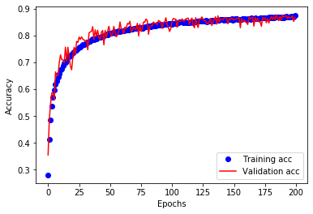

```python
import matplotlib.pyplot as plt
%matplotlib inline

acc = history.history['acc']
val_acc = history.history['val_acc']

epochs = range(len(acc))

plt.plot(epochs, acc, 'bo', label='Training acc')
plt.plot(epochs, val_acc, 'r', label='Validation acc')
plt.xlabel('Epochs')
plt.ylabel('Accuracy')
plt.legend()
plt.show()
```

## 3. Train (again) and evaluate the model

- To this end, you have found the "best" hyper-parameters.
- Now, fix the hyper-parameters and train the network on the entire training set (all the 50K training samples)
- Evaluate your model on the test set.

### 3.1. Train the model on the entire training set

Why? Previously, you used 40K samples for training; you wasted 10K samples for the sake of hyper-parameter tuning. Now you already know the hyper-parameters, so why not using all the 50K samples for training?

```python
from keras import optimizers

learning_rate = 3E-4 # to be tuned!

model.compile(loss='categorical_crossentropy',
              optimizer=optimizers.RMSprop(lr=learning_rate),
              metrics=['acc'])
```

```python
datagen = ImageDataGenerator(
    featurewise_center=False,
    samplewise_center=False,
    featurewise_std_normalization=False,
    samplewise_std_normalization=False,
    zca_whitening=False,
    rotation_range=20,
    width_shift_range=0.2,
    height_shift_range=0.2,
    horizontal_flip=True,
    vertical_flip=False
    )
datagen.fit(x_train)
```

```python
batch_size = 64
history = model.fit_generator(datagen.flow(x_train, y_train_vec, batch_size=batch_size), steps_per_epoch=x_train.shape[0]//batch_size,epochs=200, verbose=2)
```

```
 - 18s - loss: 1.8698 - acc: 0.3096
 - 17s - loss: 1.4693 - acc: 0.4595
 - 17s - loss: 1.2918 - acc: 0.5307
 - 18s - loss: 1.1853 - acc: 0.5765
 - 17s - loss: 1.1068 - acc: 0.6046
 - 17s - loss: 1.0526 - acc: 0.6268
 - 17s - loss: 1.0039 - acc: 0.6455
 - 17s - loss: 0.9718 - acc: 0.6572
 - 17s - loss: 0.9353 - acc: 0.6723
 - 18s - loss: 0.9079 - acc: 0.6825
 - 17s - loss: 0.8824 - acc: 0.6928
 - 17s - loss: 0.8609 - acc: 0.7009
 - 18s - loss: 0.8424 - acc: 0.7086
 - 17s - loss: 0.8209 - acc: 0.7145
 - 17s - loss: 0.7939 - acc: 0.7268
 - 18s - loss: 0.7889 - acc: 0.7285
 - 17s - loss: 0.7706 - acc: 0.7332
 - 17s - loss: 0.7629 - acc: 0.7369
 - 18s - loss: 0.7491 - acc: 0.7437
 - 17s - loss: 0.7338 - acc: 0.7467
 - 17s - loss: 0.7223 - acc: 0.7524
 - 18s - loss: 0.7146 - acc: 0.7561
 - 17s - loss: 0.7008 - acc: 0.7604
 - 17s - loss: 0.6939 - acc: 0.7634
 - 17s - loss: 0.6857 - acc: 0.7649
 - 17s - loss: 0.6661 - acc: 0.7708
 - 17s - loss: 0.6659 - acc: 0.7724
 - 18s - loss: 0.6574 - acc: 0.7740
 - 17s - loss: 0.6493 - acc: 0.7793
 - 17s - loss: 0.6436 - acc: 0.7808
 - 18s - loss: 0.6363 - acc: 0.7813
 - 17s - loss: 0.6286 - acc: 0.7845
 - 17s - loss: 0.6234 - acc: 0.7874
 - 18s - loss: 0.6129 - acc: 0.7902
 - 18s - loss: 0.6102 - acc: 0.7928
 - 17s - loss: 0.6078 - acc: 0.7928
 - 18s - loss: 0.6066 - acc: 0.7935
 - 17s - loss: 0.5976 - acc: 0.7946
 - 17s - loss: 0.5899 - acc: 0.8006
 - 18s - loss: 0.5823 - acc: 0.7990
```

[output cut: 145 more lines]

```
 - 17s - loss: 0.3895 - acc: 0.8679
 - 17s - loss: 0.3901 - acc: 0.8696
 - 17s - loss: 0.3938 - acc: 0.8671
 - 18s - loss: 0.3866 - acc: 0.8683
 - 18s - loss: 0.3947 - acc: 0.8657
 - 18s - loss: 0.3905 - acc: 0.8674
 - 17s - loss: 0.3885 - acc: 0.8682
 - 18s - loss: 0.3912 - acc: 0.8670
 - 17s - loss: 0.3876 - acc: 0.8680
 - 17s - loss: 0.3923 - acc: 0.8676
 - 18s - loss: 0.3817 - acc: 0.8706
 - 17s - loss: 0.3868 - acc: 0.8705
 - 17s - loss: 0.3819 - acc: 0.8717
 - 18s - loss: 0.3853 - acc: 0.8700
 - 17s - loss: 0.3852 - acc: 0.8689
```

### 3.2. Evaluate the model on the test set

Do NOT used the test set until now. Make sure that your model parameters and hyper-parameters are independent of the test set.

```python
loss_and_acc = model.evaluate(x_test, y_test_vec)
print('loss = ' + str(loss_and_acc[0]))
print('accuracy = ' + str(loss_and_acc[1]))
```

```
loss = 0.43090935096740723
accuracy = 0.8626999855041504
```

```python
!jupyter nbconvert --to html HM4.ipynb
```

[output not shown]

[output cut: 144 more lines]

[output not shown]

[output not shown]